# Homework 3: Samplers

Ben Pelczynski

2024-11-03

# Part 1:

```r
#Make sure you install the Rmpfr library
library(Rmpfr)
dat = read.csv("coaldisasters-ds6040.csv")


gibbs_sampler = function(iter, dat, a_mu, b_mu, a_lambda, b_lambda){

  mu_vec = vector()
  lambda_vec = vector()
  k_prob_mat = matrix(nrow = iter+1, ncol = 111)
  k_samp_vec = vector()
  #Initialize sampler
    mu_vec[1] = rgamma(1,a_mu, rate  = b_mu)
  lambda_vec[1] = rgamma(1,a_lambda, rate = b_lambda)
  k_prob_mat[1,] = rep(1/111, 111)
  k_samp_vec[1] = 56

  #Sampler
  for(i in 2:(iter+1)){
    mu_vec[i] = rgamma(1, shape = a_mu + sum(dat[1:k_samp_vec[i-1], "Count"]),
                       rate = k_samp_vec[i-1] + b_mu)
    lambda_vec[i] = rgamma(1, shape = a_lambda + sum(dat[(k_samp_vec[i-1]+1):112, "Count"]),
                       rate = 112 - k_samp_vec[i-1] + b_lambda)

    l_temp = vector()
  for(j in 1:111){
    l_temp[j] = sum(log(mpfr(dpois(dat[1:j,2], lambda = rep(mu_vec[i],j)), precBits = 100))) + sum(log(mpfr(dpois(dat[(j+1):112,2], lambda = rep(lambda_vec[i],112-j)), precBits = 100)))
  }
  l_temp <- mpfr(l_temp, precBits = 100)
  k_prob_mat[i,] = as.numeric(exp(l_temp)/sum(exp(l_temp)))
  k_samp_vec[i] = sample(size = 1,1:111, prob = k_prob_mat[i,])
  }
  toReturn = data.frame(mu = mu_vec, lambda = lambda_vec, k = k_samp_vec)

  return(toReturn)
}

test = gibbs_sampler(1000, dat, a_mu = 1, b_mu = 1, a_lambda = 1, b_lambda = 1)
```

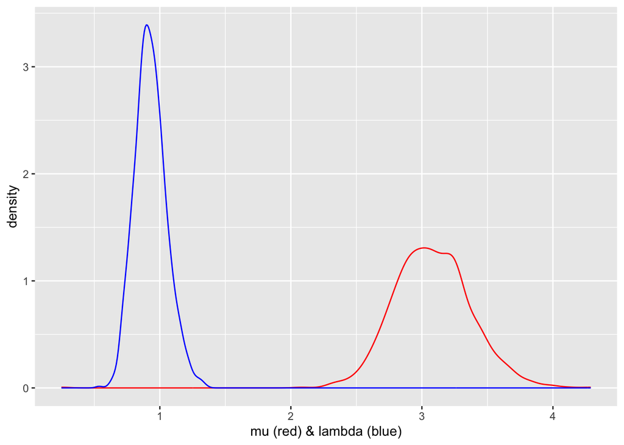

```r
library(ggplot2)
library(dplyr)
ggplot(test) + geom_density(aes(x = mu), color='red') + geom_density(aes(x = lambda), color='blue') + xlab('mu (red) & lambda (blue)')
```

```r
mu_EAP = mean(test$mu)
lambda_EAP = mean(test$lambda)
mu_CI= quantile(test$mu, probs = c(0.025, 0.975))
lambda_CI = quantile(test$lambda, probs = c(0.025, 0.975))
tibble(mu_EAP, mu_CI, lambda_EAP, lambda_CI)
```

```
## # A tibble: 2 × 4
##   mu_EAP mu_CI lambda_EAP lambda_CI
##    <dbl> <dbl>      <dbl>     <dbl>
## 1   3.08  2.54      0.929     0.717
## 2   3.08  3.68      0.929     1.19
```

```r
test %>% count(k) %>% arrange(desc(n)) %>% head(5)
```

```
##    k   n
## 1 41 240
## 2 40 182
## 3 39 130
## 4 37 111
## 5 42  96
```

### (a)

The EAP and credible intervals of $\mu$ and $\lambda$ suggest that, at the changepoint the rate of coal mining disasters changes from approximately 3.07 (with a variation of about 0.57) to a rate of approximately 0.92 (with a variation of about 0.23). Subsequently, the number of coal mining disasters shifts from a distribution of Poisson(~3.07) to a distribution of Poisson(~0.92), and thus *something* happened at the changepoint to greatly decrease the amount of mining disasters. Additionally, the lower variance of $\lambda$ suggests that the *something* was not only able to lower the rate of disasters, it was able to do so consistently. The most likely year of the changepoint is $1850 + [k = 41] = 1891$.

### (b)

The EAPs/CIs aren’t necessarily the most appropriate to report for the year of the changepoint because the year of the changepoint is the year of the changepoint is inherently based on the EAPs/CIs of the $\mu$ and $\lambda$, so reporting them both is redundant.